# question2.1

```r
data = get(load('../datasets/GoldenGate.RData'))
ts.gg<- ts(data[,'traffic'], start=1968, frequency=12)
```

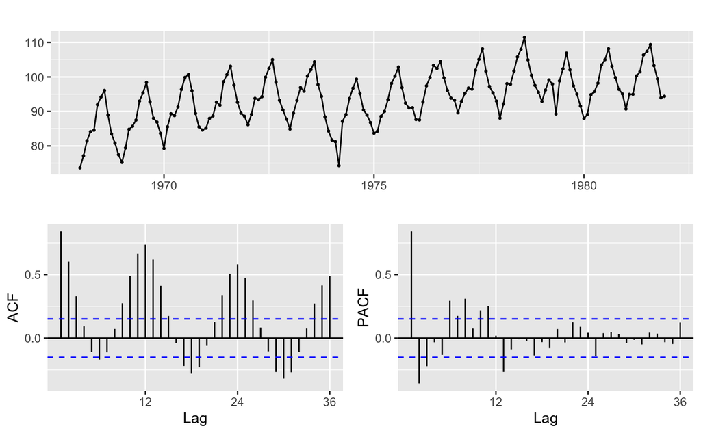

```r
ggtsdisplay(ts.gg)
```

# a

For the time series selected generate time series which are corrected for trend, for seasonality and for both trend and seasonality. Perform an Exploratory Data Analysis (including fingerprinting!) for the results!

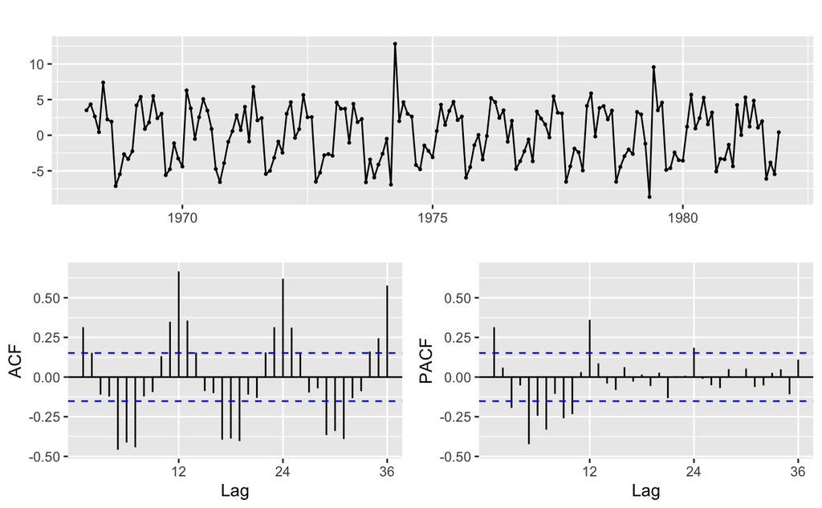

```r
diff1.gg <- diff(ts.gg, differences = 1)
ggtsdisplay(diff1.gg)
```

```r
nsdiffs(ts.gg)
```

```
[1] 1
```

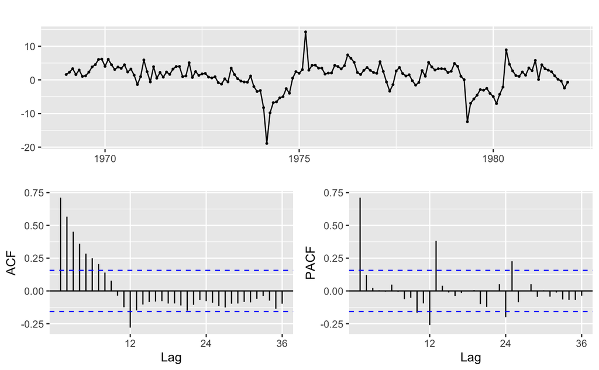

```r
sd1.gg <- diff(ts.gg, lag=12, differences = 1)
ggtsdisplay(sd1.gg)
```

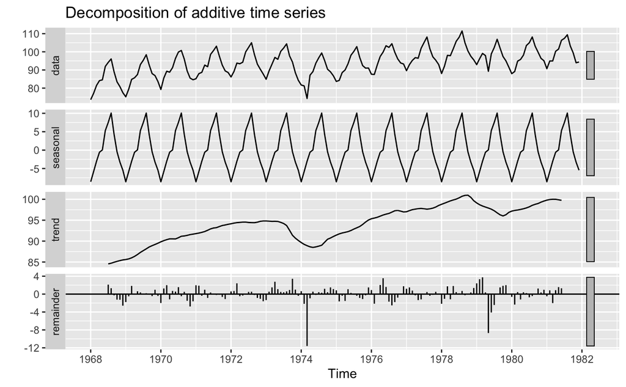

```r
# remove trend and seasonality

add.gg <- decompose(ts.gg, type='additive')
autoplot(add.gg)
```

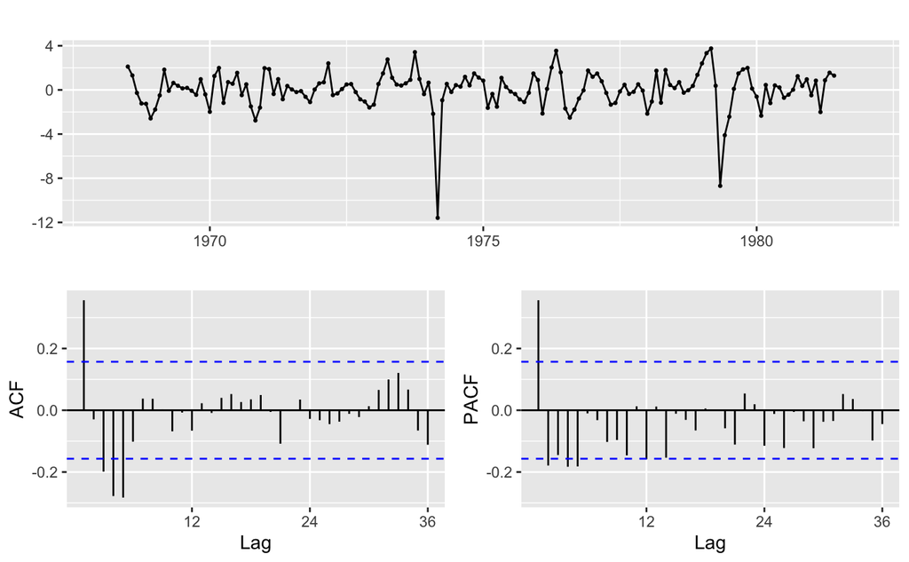

```r
ggtsdisplay(add.gg$random)
```

# b

For the generated time series, corrected both for trend and seasonality select an adequate Exponential Smoothing Model to predict future values. Fit the model by estimating its parameters and give an interpretation for the parametervalues obtained. Verify the model on the basis of the residuals, their (partial) autocorrelations and Goodness-of-Fit measures such as RMSE, MAE and MAPE.

```r
trend <- diff(ts.gg, lag=12, differences = 1)
trend.season <- diff(trend, lag=12, differences = 1)
```

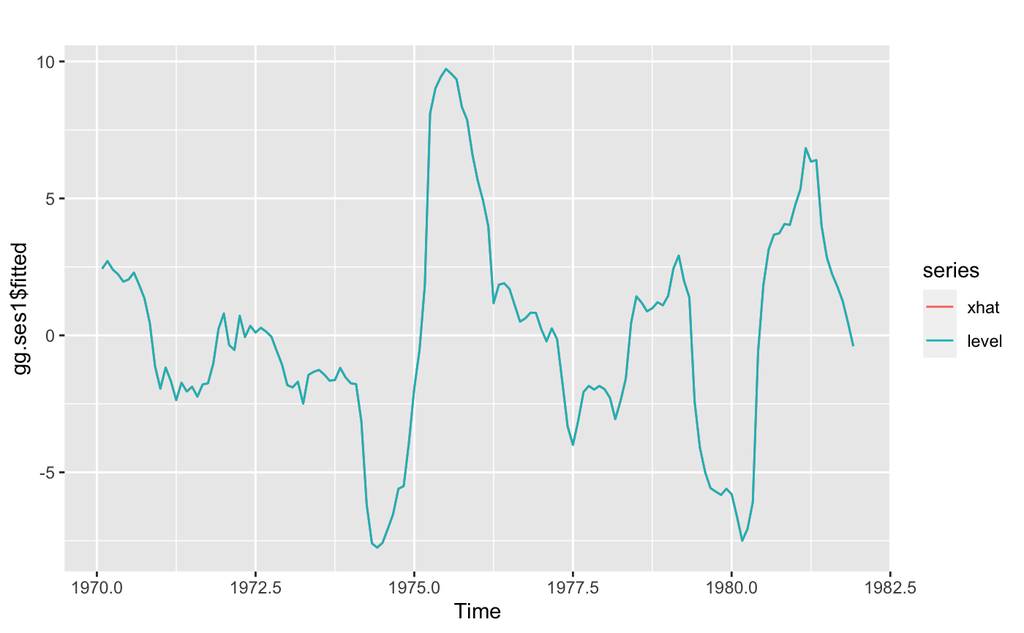

```r
#fc <- ses(ts.gg, h=15)
gg.ses1 <- HoltWinters(trend.season, alpha=0.2, beta=FALSE, gamma=FALSE)
autoplot(gg.ses1$fitted)
```

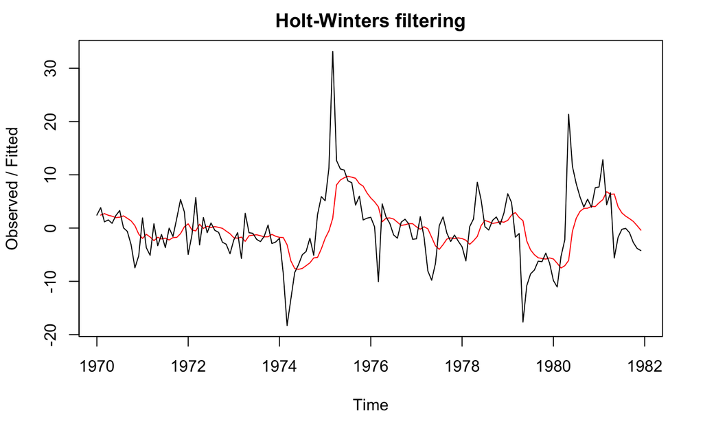

```r
plot(gg.ses1)
```

```r
with(gg.ses1,accuracy(fitted,x))
```

```
                 ME     RMSE      MAE       MPE     MAPE      ACF1 Theil's U
Test set -0.1257156 5.770593 3.727369 -144.1578 400.4806 0.5034633 0.5289795
```

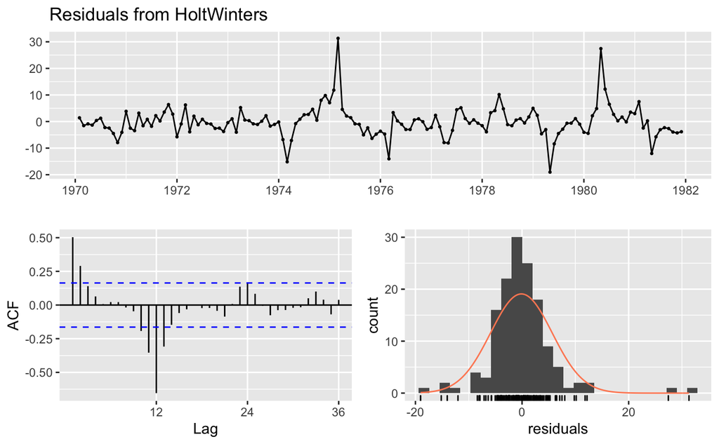

```r
checkresiduals(gg.ses1)
```

# c

For the generated time series, corrected only for seasonality select an adequate Exponential Smoothing Model to predict future values. Fit the model by estimating its parameters and give an interpretation for the parametervalues obtained. Verify the model on the basis of the residuals, their (partial) autocorrelations and Goodness-of-Fit measures such as RMSE, MAE and MAPE.

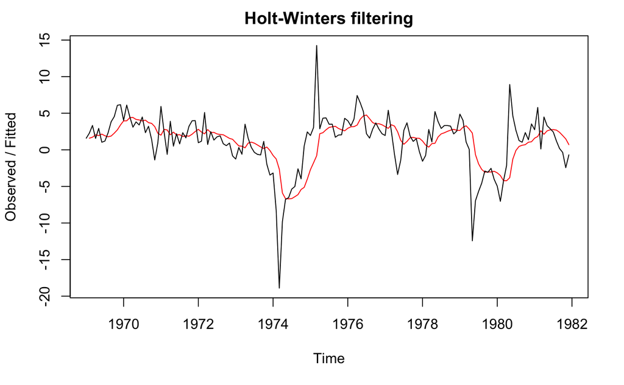

```r
season <- diff(ts.gg, lag=12, differences = 1)
gg.ses1 <- HoltWinters(season, alpha=0.2, beta=FALSE, gamma=FALSE)
plot(gg.ses1)
```

```r
with(gg.ses1,accuracy(fitted,x))
```

```
                  ME     RMSE      MAE       MPE     MAPE      ACF1 Theil's U
Test set -0.03739559 3.254509 2.063995 -9.330685 147.9775 0.5082373  1.167545
```

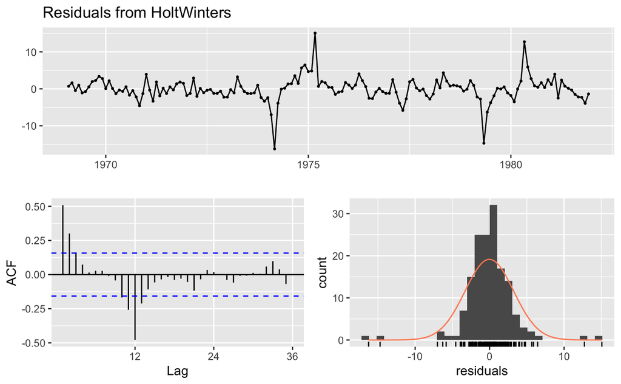

```r
checkresiduals(gg.ses1)
```

# d

For the generated time series, corrected only for trend select an adequate Exponential Smoothing Model to predict future values. Fit the model by estimating its parameters and give an interpretation for the parametervalues obtained. Verify the model on the basis of the residuals, their (partial) autocorrelations and Goodness-of-Fit measures such as RMSE, MAE and MAPE.

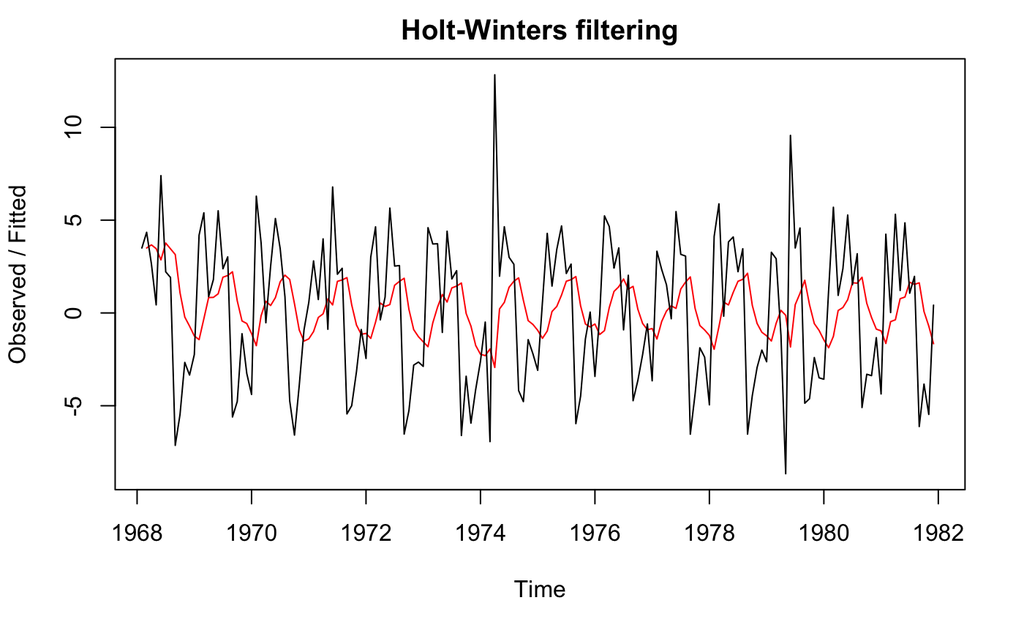

```r
trend <- diff(ts.gg, differences = 1)
gg.ses1 <- HoltWinters(trend, alpha=0.2, beta=FALSE, gamma=FALSE)
plot(gg.ses1)
```

```r
with(gg.ses1,accuracy(fitted,x))
```

```
                 ME     RMSE     MAE     MPE     MAPE      ACF1 Theil's U
Test set -0.1428275 4.191851 3.29407 101.797 131.8553 0.2611239  1.054135
```

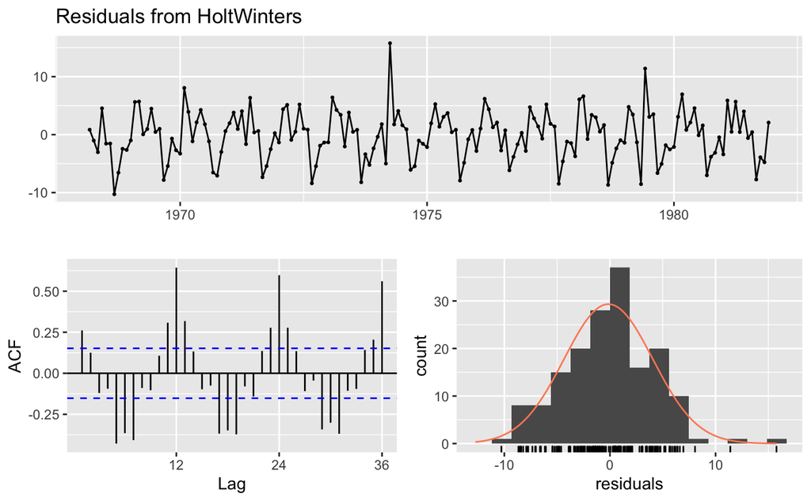

```r
checkresiduals(gg.ses1)
```

# e

For the original time series, not corrected for trend and seasonality, select an adequate Exponential Smoothing Model to predict future values. Fit the model by estimating its parameters and give an interpretation for the parametervalues obtained. Verify the model on the basis of the residuals, their (partial) autocorrelations and Goodness-of-Fit measures such as RMSE, MAE and MAPE.

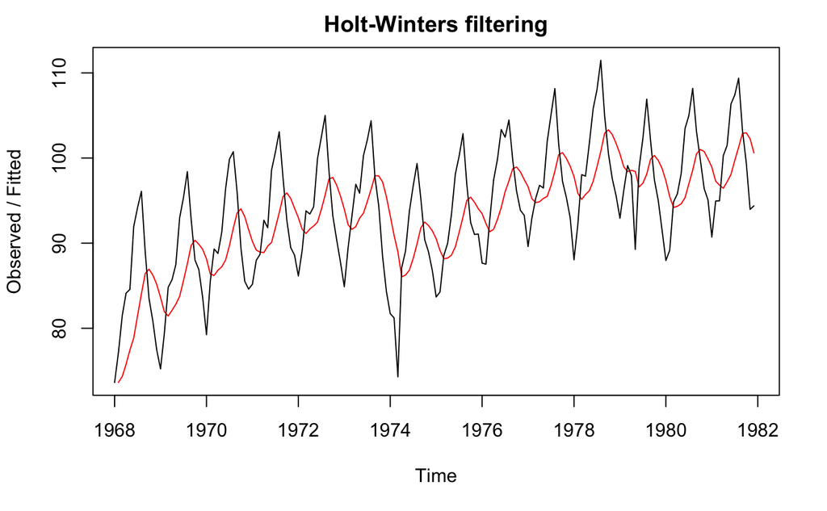

```r
gg.ses1 <- HoltWinters(ts.gg, alpha=0.2, beta=FALSE, gamma=FALSE)
plot(gg.ses1)
```

```r
with(gg.ses1,accuracy(fitted,x))
```

```
                ME     RMSE      MAE       MPE     MAPE      ACF1 Theil's U
Test set 0.7700445 6.237088 5.363484 0.4891453 5.732738 0.7680181   1.56529
```

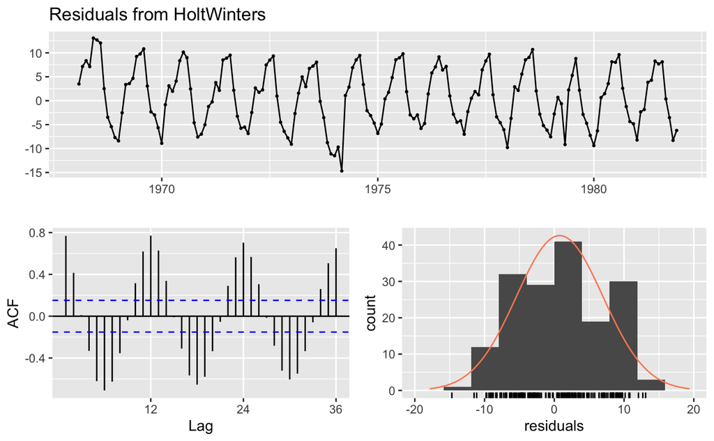

```r
checkresiduals(gg.ses1)
```